# Exam 1

## Exam 1

#### Question

1. Una empresa desarrolla un juego para computador. La gráfica muestra la proyección que hizo la empresa acerca de la cantidad de usuarios que tendrá el juego luego de su lanzamiento.

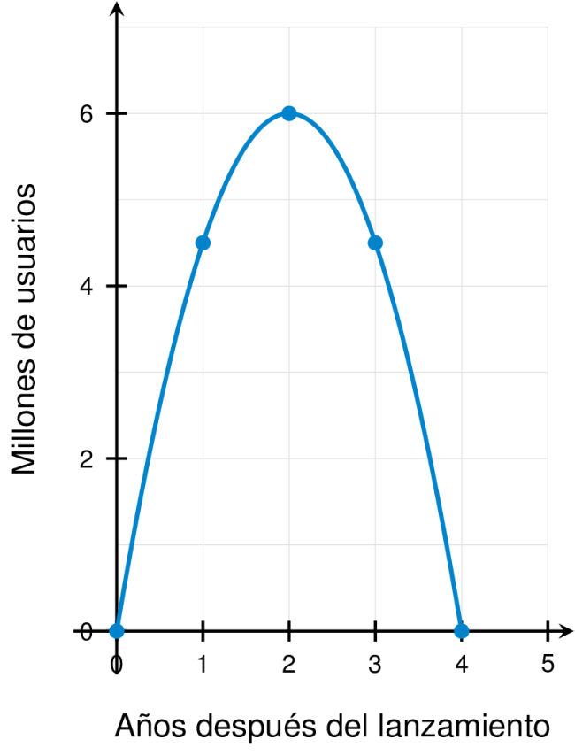

   ¿Qué ecuación corresponde con la gráfica que relaciona el tiempo $x$ desde el lanzamiento del juego con la cantidad $y$ de usuarios que tiene?
   1. $y = 1.5x^2 - 6x$
   2. $y = -1.5x^2 + 4x$
   3. $y = -1.5x^2 + 6x$
   4. $y = -1.5x^2 + 6x + -2$

#### Solution

   Para encontrar la ecuación correcta, debemos analizar las características de la parábola mostrada en la gráfica:

   **1. Identificar puntos clave:**
   - La gráfica pasa por el origen: $(0, 0)$
   - La gráfica tiene una raíz (cruza el eje $x$) en $x = 4$
   - El punto máximo (vértice) está aproximadamente en $x = 2$, $y = 6$

   **2. Analizar la forma:**
   - La parábola abre hacia abajo (concavidad negativa), lo que indica que el coeficiente de $x^2$ debe ser **negativo**
   - Tiene forma $y = ax^2 + bx + c$ con $a < 0$

   **3. Determinar los coeficientes:**

   Como la parábola pasa por $(0, 0)$, sabemos que $c = 0$.

   Como tiene raíces en $x = 0$ y $x = 4$, podemos factorizar:
   $$y = -k \cdot x(x - 4)$$

   Con $k = 1.5$:
   $$y = -1.5 x^2 + 6 x$$

   **4. Verificación:**
   - En $x = 0$: $y = 0$ (Correcto)
   - En $x = 4$: $y = -1.5 \cdot 4^2 + 6 \cdot 4 = 0$ (Correcto)
   - Vértice en $x = -\frac{b}{2a} = -\frac{6}{2 \cdot (-1.5)} = 2$ (Correcto)

   **Respuesta correcta:** $y = -1.5x^2 + 6x$
   1. Falso. Esta ecuación no representa correctamente la parábola mostrada.
   2. Falso. Esta ecuación no representa correctamente la parábola mostrada.
   3. Verdadero. Esta es la ecuación correcta.
   4. Falso. Esta ecuación no representa correctamente la parábola mostrada.